# Demo: Getting Started with the CAS Server

### 1. Import Packages

Visit the documentation for the SWAT [(SAS Scripting Wrapper for Analytics Transfer)](https://sassoftware.github.io/python-swat/index.html) package.

```python
import swat
import pandas as pd
```

### 2. Connect to the CAS Server

To connect to the CAS server, you need

- the host name
- the port number
- authentication

Visit the documentation [Getting Started with SAS® Viya® for Python](https://documentation.sas.com/doc/en/pgmsascdc/v_016/caspg3/titlepage.htm?homeOnFail) for more information about connecting to CAS.

**Note**: Be aware that connecting to the CAS server can be implemented in various ways, so you might need to see your system administrator about how to make a connection. Please follow company policy regarding authentication. *Never place your password in plain text. This course adds the password in plain text for training purposes only.*

a. Make a connection to the CAS server and name the variable **conn**.

```python
conn = swat.CAS('server.demo.sas.com', 30571, 'student', 'Metadata0')
```

b. Print the value of the **conn** variable. Notice that it contains connection information to the CAS server. A random session name and session ID is assigned.

```python
print(conn)
```

```
CAS('server.demo.sas.com', 30571, 'student', protocol='http', name='py-session-1', session='8b6056ed-99cd-a14c-bcd1-c9b8ca6a123c')
```

c. Print the type of the **conn** variable. Notice that it's a **CAS** connection object.

```python
type(conn)
```

```
swat.cas.connection.CAS
```

### 3. Explore the CAS Session Using CAS Actions

a. Use the [session.listSessions](https://go.documentation.sas.com/doc/en/pgmsascdc/v_016/caspg/cas-session-listsessions.htm?homeOnFail) action to display a list of CAS sessions.

```python
conn.session.listSessions()
```

**§ Session**

|  | SessionName | UUID | State | Authentication | Userid |
| --- | --- | --- | --- | --- | --- |
| 0 | py-session-1:Thu Mar 17 20:27:19 2022 | 8b6056ed-99cd-a14c-bcd1-c9b8ca6a123c | Connected | OAuth | student |

elapsed 0.000784s · user 0.000668s · mem 0.327MB

b. You can also specify the action without the action set. Here, the connection object **conn** is specified, followed by the CAS action listSesssions. Typically, throughout this course, only the action name is used. Execute the cell. Notice that the results are identical.

```python
conn.listSessions()
```

**§ Session**

|  | SessionName | UUID | State | Authentication | Userid |
| --- | --- | --- | --- | --- | --- |
| 0 | py-session-1:Thu Mar 17 20:27:19 2022 | 8b6056ed-99cd-a14c-bcd1-c9b8ca6a123c | Connected | OAuth | student |

elapsed 0.000865s · user 0.000739s · mem 0.327MB

c. Use the [sessionProp.listSessOpts](https://go.documentation.sas.com/doc/en/pgmsascdc/v_016/caspg/cas-sessionprop-listsessopts.htm) action to display the session options and session values.

```python
conn.listSessOpts()
```

**§ SessOpts**

|  | Name | UsageType | Type | Value | Default Value | Group | Min | Max | Description |
| --- | --- | --- | --- | --- | --- | --- | --- | --- | --- |
| 0 | appTag | Session | String |  |  | Action | 0 | 0 | specifies the string to prefix to log messages. |
| 1 | caslib | Session | String | CASUSER(student) |  | Caslib | 0 | 0 | specifies the caslib name to set as the active... |
| 2 | collate | Session | String | UCA | UCA | Sort | 0 | 0 | specifies the collating sequence for sorting. |
| 3 | locale | Session | String | en_US | en_US | Localization | 0 | 0 | specifies the locale to use for sorting and fo... |
| 4 | logFlushTime | Session | Integer | 100 | 100 | Log | -1 | 86400 | specifies the log flush time, in milliseconds.... |
| 5 | yearcutoff | Session | Integer | 1940 | 1940 | Session | 1582 | 19900 | Specifies the first year of a 100-year span th... |
| 6 | maxTableMem | Session | Integer | 16777216 | 16777216 | Caslib | 0 | 0 | specifies the maximum amount of memory, in byt... |
| 7 | metrics | Session | Boolean | 0 | 0 | Log | 0 | 1 | when set to True, action metrics are displayed. |
| 8 | nWorkers | Session | Integer | 0 | 0 | Session | 0 | 5000 | specifies the number of worker nodes associate... |
| 9 | subsetSessionCopies | Session | Integer | 0 | 0 | Session | 0 | 5000 | specifies number of backup copies of blocks fo... |
| 10 | timeout | Session | Integer | 60 | 60 | Session | 0 | 31536000 | specifies the session time-out. |
| 11 | timeZone | Session | String | Etc/GMT |  | Session | 0 | 0 | specifies the time zone offset, in hours, from... |
| 12 | messageLevel | Session | String | all | all | Log | 0 | 0 | specifies the log message level. |
| 13 | cmplib | Session | String |  |  | CMP | 0 | 0 | specifies one or more SAS data sets that conta... |
| 14 | dataStepReplaceTable | Session | Boolean | 1 | 1 | DATA Step | 0 | 1 | specifies whether DATA step can replace an exi... |
| 15 | cmpopt | Session | String |  |  | CMP | 0 | 0 | specifies code generation optimizations. |
| 16 | debugopt | Session | String |  |  | Session | 0 | 0 | Debugger options |
| 17 | dataStepMsgSumLevel | Session | String | ALL | ALL | DATA Step | 0 | 0 | specifies the DATA step message summary level.... |
| 18 | dataStepMergeNoBy | Session | String | NOWARN | NOWARN | DATA Step | 0 | 0 | when a DATA step merge is run with no BY state... |
| 19 | dqSetupLoc | Session | String | QKB CI 32 |  | Data Quality | 0 | 0 | specifies the name of the default QKB to use f... |
| 20 | dqLocale | Session | String | (ENUSA) |  | Data Quality | 0 | 0 | specifies the default locale to use for data q... |
| 21 | intervalds | Session | String |  |  | Input Control | 0 | 0 | specifies interval object pairs. |
| 22 | eventds | Session | String |  |  | Input Control | 0 | 0 | specifies one or more event objects that defin... |
| 23 | dataStepFmtErr | Session | Boolean | 1 | 1 | DATA Step | 0 | 1 | when set to True, the DATA step generates an e... |
| 24 | dqQKBRepoLoc | Session | String | ReferenceData | ReferenceData | Data Quality | 0 | 0 | specifies the name of the caslib where QKBs ar... |
| 25 | useGpu | Session | String | ALWAYS | ALWAYS | Session | 0 | 0 | specifies to offload work to a GPU, if available. |
| 26 | azureTenantId | Session | String |  |  | Session | 0 | 0 | specifies the tenant ID for Azure storage. |
| 27 | historyLineLength | Session | Integer | 8192 | 8192 | Session | 8192 | 8388608 | specifies the maximum history line length. |
| 28 | dateStyle | Session | String | LOCALE | LOCALE | Localization | 0 | 0 | Specifies the sequence of month, day, and year... |

elapsed 0.00163s · user 0.0014s · sys 0.000109s · mem 0.653MB

d. Modify CAS session options using the [sessionProp.setSessOpt](https://go.documentation.sas.com/doc/en/pgmsascdc/v_016/caspg/cas-sessionprop-setsessopt.htm) action with the name of the option to modify as a parameter. Here the **timeout** parameter is specified with a new value of *3600*. Then the listSessOpts action is executed to view the new value of the **timeout** option.

```python
conn.setSessOpt(timeout = 3600)
conn.listSessOpts()
```

**§ SessOpts**

|  | Name | UsageType | Type | Value | Default Value | Group | Min | Max | Description |
| --- | --- | --- | --- | --- | --- | --- | --- | --- | --- |
| 0 | appTag | Session | String |  |  | Action | 0 | 0 | specifies the string to prefix to log messages. |
| 1 | caslib | Session | String | CASUSER(student) |  | Caslib | 0 | 0 | specifies the caslib name to set as the active... |
| 2 | collate | Session | String | UCA | UCA | Sort | 0 | 0 | specifies the collating sequence for sorting. |
| 3 | locale | Session | String | en_US | en_US | Localization | 0 | 0 | specifies the locale to use for sorting and fo... |
| 4 | logFlushTime | Session | Integer | 100 | 100 | Log | -1 | 86400 | specifies the log flush time, in milliseconds.... |
| 5 | yearcutoff | Session | Integer | 1940 | 1940 | Session | 1582 | 19900 | Specifies the first year of a 100-year span th... |
| 6 | maxTableMem | Session | Integer | 16777216 | 16777216 | Caslib | 0 | 0 | specifies the maximum amount of memory, in byt... |
| 7 | metrics | Session | Boolean | 0 | 0 | Log | 0 | 1 | when set to True, action metrics are displayed. |
| 8 | nWorkers | Session | Integer | 0 | 0 | Session | 0 | 5000 | specifies the number of worker nodes associate... |
| 9 | subsetSessionCopies | Session | Integer | 0 | 0 | Session | 0 | 5000 | specifies number of backup copies of blocks fo... |
| 10 | timeout | Session | Integer | 3600 | 60 | Session | 0 | 31536000 | specifies the session time-out. |
| 11 | timeZone | Session | String | Etc/GMT |  | Session | 0 | 0 | specifies the time zone offset, in hours, from... |
| 12 | messageLevel | Session | String | all | all | Log | 0 | 0 | specifies the log message level. |
| 13 | cmplib | Session | String |  |  | CMP | 0 | 0 | specifies one or more SAS data sets that conta... |
| 14 | dataStepReplaceTable | Session | Boolean | 1 | 1 | DATA Step | 0 | 1 | specifies whether DATA step can replace an exi... |
| 15 | cmpopt | Session | String |  |  | CMP | 0 | 0 | specifies code generation optimizations. |
| 16 | debugopt | Session | String |  |  | Session | 0 | 0 | Debugger options |
| 17 | dataStepMsgSumLevel | Session | String | ALL | ALL | DATA Step | 0 | 0 | specifies the DATA step message summary level.... |
| 18 | dataStepMergeNoBy | Session | String | NOWARN | NOWARN | DATA Step | 0 | 0 | when a DATA step merge is run with no BY state... |
| 19 | dqSetupLoc | Session | String | QKB CI 32 |  | Data Quality | 0 | 0 | specifies the name of the default QKB to use f... |
| 20 | dqLocale | Session | String | (ENUSA) |  | Data Quality | 0 | 0 | specifies the default locale to use for data q... |
| 21 | intervalds | Session | String |  |  | Input Control | 0 | 0 | specifies interval object pairs. |
| 22 | eventds | Session | String |  |  | Input Control | 0 | 0 | specifies one or more event objects that defin... |
| 23 | dataStepFmtErr | Session | Boolean | 1 | 1 | DATA Step | 0 | 1 | when set to True, the DATA step generates an e... |
| 24 | dqQKBRepoLoc | Session | String | ReferenceData | ReferenceData | Data Quality | 0 | 0 | specifies the name of the caslib where QKBs ar... |
| 25 | useGpu | Session | String | ALWAYS | ALWAYS | Session | 0 | 0 | specifies to offload work to a GPU, if available. |
| 26 | azureTenantId | Session | String |  |  | Session | 0 | 0 | specifies the tenant ID for Azure storage. |
| 27 | historyLineLength | Session | Integer | 8192 | 8192 | Session | 8192 | 8388608 | specifies the maximum history line length. |
| 28 | dateStyle | Session | String | LOCALE | LOCALE | Localization | 0 | 0 | Specifies the sequence of month, day, and year... |

elapsed 0.00142s · user 0.000274s · sys 0.00108s · mem 0.653MB

e. Use the [builtins.actionSetInfo](https://go.documentation.sas.com/doc/en/pgmsascdc/v_016/caspg/cas-builtins-actionsetinfo.htm?homeOnFail) action to display all of the available action sets. By default, actionSetInfo shows all loaded action sets.

**Note:** Think of an action set as a package, and actions within an action set as methods.

```python
conn.actionSetInfo()
```

**§ setinfo**

Action set information

|  | actionset | label | loaded | extension | version | product_name | user_defined |
| --- | --- | --- | --- | --- | --- | --- | --- |
| 0 | accessControl | Access Controls | 1 | tkacon | V.04.00M0P10172021 | tkcas | false |
| 1 | accessControl | Access Controls | 1 | casmeta | V.04.00M0P10172021 | tkcas | false |
| 2 | builtins | Builtins | 1 | tkcasablt | V.04.00M0P10172021 | tkcas | false |
| 3 | configuration | Server Properties | 1 | tkcascfg | V.04.00M0P10172021 | tkcas | false |
| 4 | dataPreprocess | Data Preprocess | 1 | tktrans | V.04.00M0P10172021 | crsstat | false |
| 5 | dataStep | DATA Step | 1 | datastep | V.04.00M0P10172021 | tkcas | false |
| 6 | percentile | Percentile | 1 | tkcasptl | V.04.00M0P10172021 | crsstat | false |
| 7 | sccasl | CASL Server | 1 | tkcaslsc | V.04.00M0P10172021 | tkcas | false |
| 8 | search | Search | 1 | casidx | V.04.00M0P10172021 | crssearch | false |
| 9 | session | Session Methods | 1 | tkcsessn | V.04.00M0P10172021 | tkcas | false |
| 10 | sessionProp | Session Properties | 1 | tkcstate | V.04.00M0P10172021 | tkcas | false |
| 11 | simple | Simple Analytics | 1 | tkimstat | V.04.00M0P10172021 | crsstat | false |
| 12 | table | Table | 1 | tkcastab | V.04.00M0P10172021 | tkcas | false |

elapsed 0.00149s · user 0.00143s · mem 0.634MB

f. You can use the help function to see the available actions within an action set. Within the help function, the builtIns action set is specified. View all the actions available within the builtins action set.

```python
help(conn.builtIns)
```

```
Help on Builtins in module swat.cas.actions object:

class Builtins(CASActionSet)
 |  Builtins
 |  Actions
 |  -------
 |  builtins.about                  : Shows the status of the server
 |  builtins.actionsetfromtable     : Restores a user-defined action set from a
 |                                    saved table
 |  builtins.actionsetinfo          : Shows the build information from loaded action
 |                                    sets
 |  builtins.actionsettotable       : Makes an in-memory table from a user-defined
 |                                    action set
 |  builtins.adduseractionsetpath   : Adds a caslib to the user-defined action set
 |                                    search path
 |  builtins.cascommon              : Provides parameters that are common to many
 |                                    actions
 |  builtins.defineactionset        : Defines a new user-defined action set
 |  builtins.describeactionset      : Describes a user-defined action set
 |  builtins.dropactionset          : Drops a user-defined action set
 |  builtins.dropuseractionsetpath  : Removes a caslib from the user-defined action
 |                                    set search path
 |  builtins.echo                   : Prints the supplied parameters to the client
 |                                    log
 |  builtins.getcacheinfo           : Retrieves information about CAS disk cache
 |                                    usage, the CAS server directory name, and the
 |                                    file system path for that cache
 |  builtins.getlicensedproductinfo : Shows the information for licensed SAS
 |                                    products
 |  builtins.getlicenseinfo         : Shows the license information for a SAS
 |                                    product
 |  builtins.help                   : Shows the parameters for an action or lists
 |                                    all available actions
 |  builtins.history                : Shows the actions that were run in this
 |                                    session
 |  builtins.httpaddress            : Shows the HTTP address for the server monitor
 |  builtins.installactionset       : Loads an action set in new sessions
 |                                    automatically
 |  builtins.listnodes              : Shows the host names used by the server
 |  builtins.loadactionset          : Loads an action set for use in this session
```

[output cut: 47 more lines]

```
 |      CAS object
 |          The registered connection object
 |      Raises
 |      ------
 |      SWATError
 |          If the connection object no longer exists
 |  ----------------------------------------------------------------------
 |  Data descriptors inherited from CASActionSet:
 |  __dict__
 |      dictionary for instance variables (if defined)
 |  __weakref__
 |      list of weak references to the object (if defined)
 |  ----------------------------------------------------------------------
 |  Data and other attributes inherited from CASActionSet:
 |  trait_names = None
```

g. In the actionSetInfo action add the all parameter with the value *True* to see all available action sets. Notice that most action sets are not loaded by default.

```python
conn.actionsetInfo(all = True)
```

**§ setinfo**

Action set information

|  | actionset | label | loaded | extension | version | product_name | user_defined |
| --- | --- | --- | --- | --- | --- | --- | --- |
| 0 | access |  | 0 | tkacon | V.04.00M0P10172021 | tkcas | false |
| 1 | accessControl | Access Controls | 1 | casmeta | V.04.00M0P10172021 | tkcas | false |
| 2 | activeLearn |  | 0 | tkaluc | V.04.00M0P10172021 | crsactivelrn | false |
| 3 | aggregation |  | 0 | tkcasagg | V.04.00M0P10172021 | crsaggregate | false |
| 4 | astore |  | 0 | astore | V.04.00M0P10172021 | crsastore | false |
| ... | ... | ... | ... | ... | ... | ... | ... |
| 134 | tsInfo |  | 0 | tsinfo | V.04.00M0P10172021 | crstmserinfo | false |
| 135 | tSne |  | 0 | tsne | V.04.00M0P10172021 | crstsne | false |
| 136 | tsReconcile |  | 0 | tkrecfor | V.04.00M0P10172021 | crsreconcile | false |
| 137 | uniTimeSeries |  | 0 | cts | V.04.00M0P10172021 | crsutmseries | false |
| 138 | varReduce |  | 0 | tkaareduce | V.04.00M0P10172021 | crsvarreduce | false |

139 rows × 7 columns

elapsed 0.548s · user 0.917s · sys 1.28s · mem 0.747MB

### 4. Working with CAS Tables - Comparing the Pandas API and CAS Actions in the SWAT Package.

Create a reference to a CAS table using the CASTable method in the variable **tbl**. Print the value of the new **tbl** variable and its type. Notice that it's a reference to an in-memory table on the CAS server and the object type is **CASTable**. Remember, this variable does not store a table, only a reference to a CAS table.

```python
tbl = conn.CASTable('cars', caslib = 'casuser')

display(type(tbl), tbl)
```

```
swat.cas.table.CASTable
```

```
CASTable('cars', caslib='casuser')
```

#### Using the SWAT Package Pandas API on a CAS Table

a. Execute the head method on the CAS table. The CAS server processes the data and then returns five rows to the client.

```python
tbl.head()
```

Selected Rows from Table CARS

|  | Make | Model | Type | Origin | DriveTrain | MSRP | Invoice | EngineSize | Cylinders | Horsepower | MPG_City | MPG_Highway | Weight | Wheelbase | Length |
| --- | --- | --- | --- | --- | --- | --- | --- | --- | --- | --- | --- | --- | --- | --- | --- |
| 0 | Acura | MDX | SUV | Asia | All | 36945.0 | 33337.0 | 3.5 | 6.0 | 265.0 | 17.0 | 23.0 | 4451.0 | 106.0 | 189.0 |
| 1 | Acura | RSX Type S 2dr | Sedan | Asia | Front | 23820.0 | 21761.0 | 2.0 | 4.0 | 200.0 | 24.0 | 31.0 | 2778.0 | 101.0 | 172.0 |
| 2 | Acura | TSX 4dr | Sedan | Asia | Front | 26990.0 | 24647.0 | 2.4 | 4.0 | 200.0 | 22.0 | 29.0 | 3230.0 | 105.0 | 183.0 |
| 3 | Acura | TL 4dr | Sedan | Asia | Front | 33195.0 | 30299.0 | 3.2 | 6.0 | 270.0 | 20.0 | 28.0 | 3575.0 | 108.0 | 186.0 |
| 4 | Acura | 3.5 RL 4dr | Sedan | Asia | Front | 43755.0 | 39014.0 | 3.5 | 6.0 | 225.0 | 18.0 | 24.0 | 3880.0 | 115.0 | 197.0 |

b. View the object type returned to the client from the head method. Notice that it's a **SASDataFrame** object.

```python
df = tbl.head()
type(df)
```

```
swat.dataframe.SASDataFrame
```

**Notes**: A **SASDataFrame** object

- is data that is local on the client. Remember that CAS can hold larger data than your local computer can handle.
- is a subclass of a **pandas.DataFrame**. You can work with **SASDataFrame** objects as you normally do a **pandas.DataFrame**.

c. Use the Pandas plot method on the client-side **SASDataFrame** object to create a bar chart. Notice you can easily work with objects returned from the CAS server with familiar Python packages.

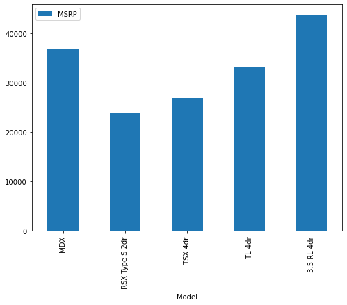

```python
df.plot(kind = 'bar', x = 'Model', y = 'MSRP',
        figsize = (8,6));
```

d. Use the value_counts method on a **CASTable** object to return the number of unique values of a CAS table column. View the object type returned from the CAS server. Notice that the CAS server returns a **Series** object to the client.

```python
s = (tbl
     .Type
     .value_counts())

display(type(s), s)
```

```
pandas.core.series.Series
```

```
Sedan     262
SUV        60
Sports     49
Wagon      30
Truck      24
Hybrid      3
dtype: int64
```

e. Use the value_counts method on a CAS table to return a **Series** object to the client. Then use the Pandas plot method on the client to plot the results. The value_counts method summarizes the CAS table on the CAS server and returns a **Series** object to the client. Then the Pandas plot method visualizes the **Series** on the client.

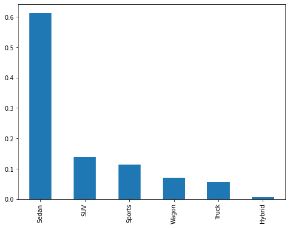

```python
(tbl
 .Type
 .value_counts(normalize = True)
 .plot(kind = 'bar', figsize = (8,6)));
```

f. Use the shape attribute to show the dimensions of the CAS table. Check the object type returned from the CAS server. Notice that the shape attribute returns a **tuple** to the client.

```python
shape = tbl.shape

display(shape, type(shape))
```

```
(428, 15)
```

```
tuple
```

**Note**:

- A **CASTable** object is a reference to an in-memory table on the CAS server.
- The SWAT package API contains many of the methods defined by the **pandas.DataFrame** object. Using these methods from the SWAT API will typically return a **CASTable**, **CASColumn**, **pandas.DataFrame**, **SASDataFrame**, or **pandas.Series** object to the client.
- Once summarized data is returned to the client, you can work with it as you normally would in Python.

#### Using a CAS Action on a CAS Table

a. Execute the [table.fetch](https://go.documentation.sas.com/doc/en/pgmsascdc/v_016/caspg/cas-table-fetch.htm?homeOnFail) action on a CAS table to return five rows. Notice that there are a variety of ways to execute an action.

```python
## Method 1
tbl.fetch(to = 5)

## Method 2
#tbl.table.fetch(to = 5)

## Method 3
#conn.fetch(table = tbl, to = 5)

## Method 4
#conn.fetch(table = {'name':'cars','caslib':'casuser'}, to = 5)
```

**§ Fetch**

Selected Rows from Table CARS

|  | Make | Model | Type | Origin | DriveTrain | MSRP | Invoice | EngineSize | Cylinders | Horsepower | MPG_City | MPG_Highway | Weight | Wheelbase | Length |
| --- | --- | --- | --- | --- | --- | --- | --- | --- | --- | --- | --- | --- | --- | --- | --- |
| 0 | Acura | MDX | SUV | Asia | All | 36945.0 | 33337.0 | 3.5 | 6.0 | 265.0 | 17.0 | 23.0 | 4451.0 | 106.0 | 189.0 |
| 1 | Acura | RSX Type S 2dr | Sedan | Asia | Front | 23820.0 | 21761.0 | 2.0 | 4.0 | 200.0 | 24.0 | 31.0 | 2778.0 | 101.0 | 172.0 |
| 2 | Acura | TSX 4dr | Sedan | Asia | Front | 26990.0 | 24647.0 | 2.4 | 4.0 | 200.0 | 22.0 | 29.0 | 3230.0 | 105.0 | 183.0 |
| 3 | Acura | TL 4dr | Sedan | Asia | Front | 33195.0 | 30299.0 | 3.2 | 6.0 | 270.0 | 20.0 | 28.0 | 3575.0 | 108.0 | 186.0 |
| 4 | Acura | 3.5 RL 4dr | Sedan | Asia | Front | 43755.0 | 39014.0 | 3.5 | 6.0 | 225.0 | 18.0 | 24.0 | 3880.0 | 115.0 | 197.0 |

elapsed 0.00197s · user 0.000395s · sys 0.00144s · mem 0.983MB

b. View the object returned to the client from a CAS action. Notice that it's a **CASResults** object. A **CASResults** object is simply a Python dictionary with some additional attributes and methods.

```python
type(tbl.fetch(to = 5))
```

```
swat.cas.results.CASResults
```

c. Store the **CASResults** object in a variable named **cr**. View the available keys in the **CASResults** object using the keys method. Notice that the keys method returns a single key, *Fetch*. If you look at the output of the previous cell, you can see that the key is located above the object.

```python
cr = tbl.fetch(to = 5)
cr.keys()
```

```
odict_keys(['Fetch'])
```

d. Call the *Fetch* key in the **CASResults** object to return the value the key holds. View the type and value of the returned object. Notice that the **CASResults** object contains a **SASDataFrame**.

```python
display(type(cr['Fetch']),
        cr['Fetch'])
```

```
swat.dataframe.SASDataFrame
```

Selected Rows from Table CARS

|  | Make | Model | Type | Origin | DriveTrain | MSRP | Invoice | EngineSize | Cylinders | Horsepower | MPG_City | MPG_Highway | Weight | Wheelbase | Length |
| --- | --- | --- | --- | --- | --- | --- | --- | --- | --- | --- | --- | --- | --- | --- | --- |
| 0 | Acura | MDX | SUV | Asia | All | 36945.0 | 33337.0 | 3.5 | 6.0 | 265.0 | 17.0 | 23.0 | 4451.0 | 106.0 | 189.0 |
| 1 | Acura | RSX Type S 2dr | Sedan | Asia | Front | 23820.0 | 21761.0 | 2.0 | 4.0 | 200.0 | 24.0 | 31.0 | 2778.0 | 101.0 | 172.0 |
| 2 | Acura | TSX 4dr | Sedan | Asia | Front | 26990.0 | 24647.0 | 2.4 | 4.0 | 200.0 | 22.0 | 29.0 | 3230.0 | 105.0 | 183.0 |
| 3 | Acura | TL 4dr | Sedan | Asia | Front | 33195.0 | 30299.0 | 3.2 | 6.0 | 270.0 | 20.0 | 28.0 | 3575.0 | 108.0 | 186.0 |
| 4 | Acura | 3.5 RL 4dr | Sedan | Asia | Front | 43755.0 | 39014.0 | 3.5 | 6.0 | 225.0 | 18.0 | 24.0 | 3880.0 | 115.0 | 197.0 |

e. Call the *Fetch* key from the **CASResults** object to return the **SASDataFrame**. Once you have the **SASDataFrame**, you can work with it as you would a **pandas.DataFrame**. Here, the Pandas plot method is executed.

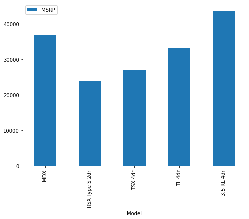

```python
(cr['Fetch']
 .plot(kind = 'bar', x = 'Model',y = 'MSRP',
       figsize=(8,6)));
```

**Notes**:

- CAS actions interact with the CAS server and return a **CASResults** object.
- A **CASResults** object is simply an ordered Python dictionary with a few extra methods and attributes added.
- **CASResults** objects are local on the client.
- Although all CAS actions return a **CASResults** object, there are no rules about how many keys are contained in the object or what objects are returned.

### 5. View the Execution of the CAS API

a. To view what the CAS API is executing on the CAS server, you can enable tracing of actions by turning on the **trace_actions** and **trace_ui_actions** options.

```python
swat.options.cas.trace_actions = True
swat.options.cas.trace_ui_actions = True
```

b. Execute the SWAT head method on the **CASTable** object. Notice that the cell shows what actions were executed on the CAS server. In this example, the head method executes the fetch action on the CAS server.

```python
tbl.head()
```

```
[table.fetch]
    _apptag = 'UI'
    _messagelevel = 'error'
    from = 1
    index = True
    sastypes = False
    table.caslib = 'casuser'
    table.name = 'cars'
    to = 5
```

Selected Rows from Table CARS

|  | Make | Model | Type | Origin | DriveTrain | MSRP | Invoice | EngineSize | Cylinders | Horsepower | MPG_City | MPG_Highway | Weight | Wheelbase | Length |
| --- | --- | --- | --- | --- | --- | --- | --- | --- | --- | --- | --- | --- | --- | --- | --- |
| 0 | Acura | MDX | SUV | Asia | All | 36945.0 | 33337.0 | 3.5 | 6.0 | 265.0 | 17.0 | 23.0 | 4451.0 | 106.0 | 189.0 |
| 1 | Acura | RSX Type S 2dr | Sedan | Asia | Front | 23820.0 | 21761.0 | 2.0 | 4.0 | 200.0 | 24.0 | 31.0 | 2778.0 | 101.0 | 172.0 |
| 2 | Acura | TSX 4dr | Sedan | Asia | Front | 26990.0 | 24647.0 | 2.4 | 4.0 | 200.0 | 22.0 | 29.0 | 3230.0 | 105.0 | 183.0 |
| 3 | Acura | TL 4dr | Sedan | Asia | Front | 33195.0 | 30299.0 | 3.2 | 6.0 | 270.0 | 20.0 | 28.0 | 3575.0 | 108.0 | 186.0 |
| 4 | Acura | 3.5 RL 4dr | Sedan | Asia | Front | 43755.0 | 39014.0 | 3.5 | 6.0 | 225.0 | 18.0 | 24.0 | 3880.0 | 115.0 | 197.0 |

c. Execute the value_counts method on the **CASTable** object. Notice that the cell shows that the columnInfo and freq actions were executed on the CAS server to produce similar results to the value_counts method.

```python
(tbl
 .Type
 .value_counts())
```

```
[table.columninfo]
    _apptag = 'UI'
    _messagelevel = 'error'
    table.caslib = 'casuser'
    table.name = 'cars'

[simple.freq]
    _apptag = 'UI'
    _messagelevel = 'error'
    includemissing = False
    table.caslib = 'casuser'
    table.name = 'cars'
```

```
Sedan     262
SUV        60
Sports     49
Wagon      30
Truck      24
Hybrid      3
dtype: int64
```

d. Execute the fetch CAS action on the **CASTable** object. Notice that the output shows that the fetch action was executed on the CAS server.

```python
tbl.fetch(to = 5)
```

```
[table.fetch]
    sastypes = False
    table.caslib = 'casuser'
    table.name = 'cars'
    to = 5
```

**§ Fetch**

Selected Rows from Table CARS

|  | Make | Model | Type | Origin | DriveTrain | MSRP | Invoice | EngineSize | Cylinders | Horsepower | MPG_City | MPG_Highway | Weight | Wheelbase | Length |
| --- | --- | --- | --- | --- | --- | --- | --- | --- | --- | --- | --- | --- | --- | --- | --- |
| 0 | Acura | MDX | SUV | Asia | All | 36945.0 | 33337.0 | 3.5 | 6.0 | 265.0 | 17.0 | 23.0 | 4451.0 | 106.0 | 189.0 |
| 1 | Acura | RSX Type S 2dr | Sedan | Asia | Front | 23820.0 | 21761.0 | 2.0 | 4.0 | 200.0 | 24.0 | 31.0 | 2778.0 | 101.0 | 172.0 |
| 2 | Acura | TSX 4dr | Sedan | Asia | Front | 26990.0 | 24647.0 | 2.4 | 4.0 | 200.0 | 22.0 | 29.0 | 3230.0 | 105.0 | 183.0 |
| 3 | Acura | TL 4dr | Sedan | Asia | Front | 33195.0 | 30299.0 | 3.2 | 6.0 | 270.0 | 20.0 | 28.0 | 3575.0 | 108.0 | 186.0 |
| 4 | Acura | 3.5 RL 4dr | Sedan | Asia | Front | 43755.0 | 39014.0 | 3.5 | 6.0 | 225.0 | 18.0 | 24.0 | 3880.0 | 115.0 | 197.0 |

elapsed 0.00259s · user 0.0011s · sys 0.00111s · mem 0.983MB

e. Set the **trace_actions** and **trace_ui_actions** options to the default *False* value.

```python
swat.options.cas.trace_actions = False
swat.options.cas.trace_ui_actions = False
```

### 6. Terminate the CAS Session

It's best practice to always terminate the CAS session when you are done.

```python
conn.terminate()
```